# Project: Investigate a Dataset - NICS Firearm Check

- Introduction
- Data Wrangling
- Exploratory Data Analysis
- Conclusions

## Introduction

> Here are some interesting questions which need no be addressed
> 1. In General. What is the distribution of gun registrations over the years?
> 2. In General. What is the distribution of gun registrations over the Monthes?
> 3. Which states have had the highest growth in gun registrations?
> 4. What is the overall trend of gun Registrations?
> 5. What is the Top 10 States in Gun Registration?
> 6. What is the overall trend of gun Registrations per Top 10 States?

>    Considering census and the association with gun registrations
>    - for 2012 Data, what is the relation between gun registration and the number of firms?
>    - What census data is most associated with high gun per State?

```python
# Importing Modules
import numpy as np
import pandas as pd
import matplotlib.pyplot as plt
import matplotlib
import seaborn as sns
%matplotlib inline
sns.set_style('darkgrid')
matplotlib.rcParams.update({'font.size': 18})
```

## Data Wrangling

### General Properties

```python
gun_data = pd.read_excel('gun_data.xlsx')
gun_data
```

|  | month | state | permit | permit_recheck | handgun | long_gun | other | multiple | admin | prepawn_handgun | ... | returned_other | rentals_handgun | rentals_long_gun | private_sale_handgun | private_sale_long_gun | private_sale_other | return_to_seller_handgun | return_to_seller_long_gun | return_to_seller_other | totals |
| --- | --- | --- | --- | --- | --- | --- | --- | --- | --- | --- | --- | --- | --- | --- | --- | --- | --- | --- | --- | --- | --- |
| 0 | 2017-09 | Alabama | 16717.0 | 0.0 | 5734.0 | 6320.0 | 221.0 | 317 | 0.0 | 15.0 | ... | 0.0 | 0.0 | 0.0 | 9.0 | 16.0 | 3.0 | 0.0 | 0.0 | 3.0 | 32019 |
| 1 | 2017-09 | Alaska | 209.0 | 2.0 | 2320.0 | 2930.0 | 219.0 | 160 | 0.0 | 5.0 | ... | 0.0 | 0.0 | 0.0 | 17.0 | 24.0 | 1.0 | 0.0 | 0.0 | 0.0 | 6303 |
| 2 | 2017-09 | Arizona | 5069.0 | 382.0 | 11063.0 | 7946.0 | 920.0 | 631 | 0.0 | 13.0 | ... | 0.0 | 0.0 | 0.0 | 38.0 | 12.0 | 2.0 | 0.0 | 0.0 | 0.0 | 28394 |
| 3 | 2017-09 | Arkansas | 2935.0 | 632.0 | 4347.0 | 6063.0 | 165.0 | 366 | 51.0 | 12.0 | ... | 0.0 | 0.0 | 0.0 | 13.0 | 23.0 | 0.0 | 0.0 | 2.0 | 1.0 | 17747 |
| 4 | 2017-09 | California | 57839.0 | 0.0 | 37165.0 | 24581.0 | 2984.0 | 0 | 0.0 | 0.0 | ... | 0.0 | 0.0 | 0.0 | 0.0 | 0.0 | 0.0 | 0.0 | 0.0 | 0.0 | 123506 |
| ... | ... | ... | ... | ... | ... | ... | ... | ... | ... | ... | ... | ... | ... | ... | ... | ... | ... | ... | ... | ... | ... |
| 12480 | 1998-11 | Virginia | 0.0 | NaN | 14.0 | 2.0 | NaN | 8 | 0.0 | NaN | ... | NaN | NaN | NaN | NaN | NaN | NaN | NaN | NaN | NaN | 24 |
| 12481 | 1998-11 | Washington | 1.0 | NaN | 65.0 | 286.0 | NaN | 8 | 1.0 | NaN | ... | NaN | NaN | NaN | NaN | NaN | NaN | NaN | NaN | NaN | 361 |
| 12482 | 1998-11 | West Virginia | 3.0 | NaN | 149.0 | 251.0 | NaN | 5 | 0.0 | NaN | ... | NaN | NaN | NaN | NaN | NaN | NaN | NaN | NaN | NaN | 408 |
| 12483 | 1998-11 | Wisconsin | 0.0 | NaN | 25.0 | 214.0 | NaN | 2 | 0.0 | NaN | ... | NaN | NaN | NaN | NaN | NaN | NaN | NaN | NaN | NaN | 241 |
| 12484 | 1998-11 | Wyoming | 8.0 | NaN | 45.0 | 49.0 | NaN | 5 | 0.0 | NaN | ... | NaN | NaN | NaN | NaN | NaN | NaN | NaN | NaN | NaN | 107 |

12485 rows × 27 columns

#### I have noticed that some columns need to be dropped as *"rental, private and return to seller sections columns"* as it will not be relevant to my investigation also notice that there is the main data which exist for all years as "'permit', 'handgun', 'long_gun','other', 'multiple'" but others categories come as an update to original data set

```python
gun_data.info()
```

```
<class 'pandas.core.frame.DataFrame'>
RangeIndex: 12485 entries, 0 to 12484
Data columns (total 27 columns):
 #   Column                     Non-Null Count  Dtype
---  ------                     --------------  -----
 0   month                      12485 non-null  object
 1   state                      12485 non-null  object
 2   permit                     12461 non-null  float64
 3   permit_recheck             1100 non-null   float64
 4   handgun                    12465 non-null  float64
 5   long_gun                   12466 non-null  float64
 6   other                      5500 non-null   float64
 7   multiple                   12485 non-null  int64
 8   admin                      12462 non-null  float64
 9   prepawn_handgun            10542 non-null  float64
```

[output cut: 19 more lines]

```python
gun_data.state.nunique()
```

```
55
```

#### Month Columns type need to be converted to a Date and any null values need to be handled after dropping the not needed columns

```python
gun_data.describe()
```

|  | permit | permit_recheck | handgun | long_gun | other | multiple | admin | prepawn_handgun | prepawn_long_gun | prepawn_other | ... | returned_other | rentals_handgun | rentals_long_gun | private_sale_handgun | private_sale_long_gun | private_sale_other | return_to_seller_handgun | return_to_seller_long_gun | return_to_seller_other | totals |
| --- | --- | --- | --- | --- | --- | --- | --- | --- | --- | --- | --- | --- | --- | --- | --- | --- | --- | --- | --- | --- | --- |
| count | 12461.000000 | 1100.000000 | 12465.000000 | 12466.000000 | 5500.000000 | 12485.000000 | 12462.000000 | 10542.000000 | 10540.000000 | 5115.000000 | ... | 1815.000000 | 990.000000 | 825.000000 | 2750.000000 | 2750.000000 | 2750.000000 | 2475.000000 | 2750.000000 | 2255.000000 | 12485.000000 |
| mean | 6413.629404 | 1165.956364 | 5940.881107 | 7810.847585 | 360.471636 | 268.603364 | 58.898090 | 4.828021 | 7.834156 | 0.165591 | ... | 1.027548 | 0.076768 | 0.087273 | 14.936000 | 11.602909 | 1.030182 | 0.402020 | 0.441818 | 0.105987 | 21595.725911 |
| std | 23752.338269 | 9224.200609 | 8618.584060 | 9309.846140 | 1349.478273 | 783.185073 | 604.814818 | 10.907756 | 16.468028 | 1.057105 | ... | 4.386296 | 0.634503 | 0.671649 | 71.216021 | 54.253090 | 4.467843 | 1.446568 | 1.528223 | 0.427363 | 32591.418387 |
| min | 0.000000 | 0.000000 | 0.000000 | 0.000000 | 0.000000 | 0.000000 | 0.000000 | 0.000000 | 0.000000 | 0.000000 | ... | 0.000000 | 0.000000 | 0.000000 | 0.000000 | 0.000000 | 0.000000 | 0.000000 | 0.000000 | 0.000000 | 0.000000 |
| 25% | 0.000000 | 0.000000 | 865.000000 | 2078.250000 | 17.000000 | 15.000000 | 0.000000 | 0.000000 | 0.000000 | 0.000000 | ... | 0.000000 | 0.000000 | 0.000000 | 0.000000 | 0.000000 | 0.000000 | 0.000000 | 0.000000 | 0.000000 | 4638.000000 |
| 50% | 518.000000 | 0.000000 | 3059.000000 | 5122.000000 | 121.000000 | 125.000000 | 0.000000 | 0.000000 | 1.000000 | 0.000000 | ... | 0.000000 | 0.000000 | 0.000000 | 0.000000 | 0.000000 | 0.000000 | 0.000000 | 0.000000 | 0.000000 | 12399.000000 |
| 75% | 4272.000000 | 0.000000 | 7280.000000 | 10380.750000 | 354.000000 | 301.000000 | 0.000000 | 5.000000 | 8.000000 | 0.000000 | ... | 0.000000 | 0.000000 | 0.000000 | 2.000000 | 4.000000 | 0.000000 | 0.000000 | 0.000000 | 0.000000 | 25453.000000 |
| max | 522188.000000 | 116681.000000 | 107224.000000 | 108058.000000 | 77929.000000 | 38907.000000 | 28083.000000 | 164.000000 | 269.000000 | 49.000000 | ... | 64.000000 | 12.000000 | 12.000000 | 1017.000000 | 777.000000 | 71.000000 | 28.000000 | 17.000000 | 4.000000 | 541978.000000 |

8 rows × 25 columns

```python
census_data = pd.read_csv('U.S. Census Data.csv')
census_data
```

|  | Fact | Fact Note | Alabama | Alaska | Arizona | Arkansas | California | Colorado | Connecticut | Delaware | ... | South Dakota | Tennessee | Texas | Utah | Vermont | Virginia | Washington | West Virginia | Wisconsin | Wyoming |
| --- | --- | --- | --- | --- | --- | --- | --- | --- | --- | --- | --- | --- | --- | --- | --- | --- | --- | --- | --- | --- | --- |
| 0 | Population estimates, July 1, 2016, (V2016) | NaN | 4,863,300 | 741,894 | 6,931,071 | 2,988,248 | 39,250,017 | 5,540,545 | 3,576,452 | 952,065 | ... | 865454 | 6651194 | 27,862,596 | 3,051,217 | 624,594 | 8,411,808 | 7,288,000 | 1,831,102 | 5,778,708 | 585,501 |
| 1 | Population estimates base, April 1, 2010, (V2... | NaN | 4,780,131 | 710,249 | 6,392,301 | 2,916,025 | 37,254,522 | 5,029,324 | 3,574,114 | 897,936 | ... | 814195 | 6346298 | 25,146,100 | 2,763,888 | 625,741 | 8,001,041 | 6,724,545 | 1,853,011 | 5,687,289 | 563,767 |
| 2 | Population, percent change - April 1, 2010 (es... | NaN | 1.70% | 4.50% | 8.40% | 2.50% | 5.40% | 10.20% | 0.10% | 6.00% | ... | 0.063 | 0.048 | 10.80% | 10.40% | -0.20% | 5.10% | 8.40% | -1.20% | 1.60% | 3.90% |
| 3 | Population, Census, April 1, 2010 | NaN | 4,779,736 | 710,231 | 6,392,017 | 2,915,918 | 37,253,956 | 5,029,196 | 3,574,097 | 897,934 | ... | 814180 | 6346105 | 25,145,561 | 2,763,885 | 625,741 | 8,001,024 | 6,724,540 | 1,852,994 | 5,686,986 | 563,626 |
| 4 | Persons under 5 years, percent, July 1, 2016, ... | NaN | 6.00% | 7.30% | 6.30% | 6.40% | 6.30% | 6.10% | 5.20% | 5.80% | ... | 0.071 | 0.061 | 7.20% | 8.30% | 4.90% | 6.10% | 6.20% | 5.50% | 5.80% | 6.50% |
| ... | ... | ... | ... | ... | ... | ... | ... | ... | ... | ... | ... | ... | ... | ... | ... | ... | ... | ... | ... | ... | ... |
| 80 | FN | Footnote on this item in place of data | NaN | NaN | NaN | NaN | NaN | NaN | NaN | NaN | ... | NaN | NaN | NaN | NaN | NaN | NaN | NaN | NaN | NaN | NaN |
| 81 | NaN | Not available | NaN | NaN | NaN | NaN | NaN | NaN | NaN | NaN | ... | NaN | NaN | NaN | NaN | NaN | NaN | NaN | NaN | NaN | NaN |
| 82 | S | Suppressed; does not meet publication standards | NaN | NaN | NaN | NaN | NaN | NaN | NaN | NaN | ... | NaN | NaN | NaN | NaN | NaN | NaN | NaN | NaN | NaN | NaN |
| 83 | X | Not applicable | NaN | NaN | NaN | NaN | NaN | NaN | NaN | NaN | ... | NaN | NaN | NaN | NaN | NaN | NaN | NaN | NaN | NaN | NaN |
| 84 | Z | Value greater than zero but less than half uni... | NaN | NaN | NaN | NaN | NaN | NaN | NaN | NaN | ... | NaN | NaN | NaN | NaN | NaN | NaN | NaN | NaN | NaN | NaN |

85 rows × 52 columns

```python
census_data.info()
```

```
<class 'pandas.core.frame.DataFrame'>
RangeIndex: 85 entries, 0 to 84
Data columns (total 52 columns):
 #   Column          Non-Null Count  Dtype
---  ------          --------------  -----
 0   Fact            80 non-null     object
 1   Fact Note       28 non-null     object
 2   Alabama         65 non-null     object
 3   Alaska          65 non-null     object
 4   Arizona         65 non-null     object
 5   Arkansas        65 non-null     object
 6   California      65 non-null     object
 7   Colorado        65 non-null     object
 8   Connecticut     65 non-null     object
 9   Delaware        65 non-null     object
```

[output cut: 44 more lines]

##### There are missing States in the census data set and almost all data type needs to be handled

```python
census_data['Fact'].unique()
```

```
array(['Population estimates, July 1, 2016,  (V2016)',
       'Population estimates base, April 1, 2010,  (V2016)',
       'Population, percent change - April 1, 2010 (estimates base) to July 1, 2016,  (V2016)',
       'Population, Census, April 1, 2010',
       'Persons under 5 years, percent, July 1, 2016,  (V2016)',
       'Persons under 5 years, percent, April 1, 2010',
       'Persons under 18 years, percent, July 1, 2016,  (V2016)',
       'Persons under 18 years, percent, April 1, 2010',
       'Persons 65 years and over, percent,  July 1, 2016,  (V2016)',
       'Persons 65 years and over, percent, April 1, 2010',
       'Female persons, percent,  July 1, 2016,  (V2016)',
       'Female persons, percent, April 1, 2010',
       'White alone, percent, July 1, 2016,  (V2016)',
       'Black or African American alone, percent, July 1, 2016,  (V2016)',
       'American Indian and Alaska Native alone, percent, July 1, 2016,  (V2016)',
       'Asian alone, percent, July 1, 2016,  (V2016)',
       'Native Hawaiian and Other Pacific Islander alone, percent, July 1, 2016,  (V2016)',
       'Two or More Races, percent, July 1, 2016,  (V2016)',
       'Hispanic or Latino, percent, July 1, 2016,  (V2016)',
       'White alone, not Hispanic or Latino, percent, July 1, 2016,  (V2016)',
       'Veterans, 2011-2015', 'Foreign born persons, percent, 2011-2015',
       'Housing units,  July 1, 2016,  (V2016)',
       'Housing units, April 1, 2010',
       'Owner-occupied housing unit rate, 2011-2015',
       'Median value of owner-occupied housing units, 2011-2015',
       'Median selected monthly owner costs -with a mortgage, 2011-2015',
       'Median selected monthly owner costs -without a mortgage, 2011-2015',
       'Median gross rent, 2011-2015', 'Building permits, 2016',
       'Households, 2011-2015', 'Persons per household, 2011-2015',
       'Living in same house 1 year ago, percent of persons age 1 year+, 2011-2015',
       'Language other than English spoken at home, percent of persons age 5 years+, 2011-2015',
       'High school graduate or higher, percent of persons age 25 years+, 2011-2015',
       "Bachelor's degree or higher, percent of persons age 25 years+, 2011-2015",
       'With a disability, under age 65 years, percent, 2011-2015',
       'Persons  without health insurance, under age 65 years, percent',
       'In civilian labor force, total, percent of population age 16 years+, 2011-2015',
       'In civilian labor force, female, percent of population age 16 years+, 2011-2015',
       'Total accommodation and food services sales, 2012 ($1,000)',
       'Total health care and social assistance receipts/revenue, 2012 ($1,000)',
       'Total manufacturers shipments, 2012 ($1,000)',
       'Total merchant wholesaler sales, 2012 ($1,000)',
       'Total retail sales, 2012 ($1,000)',
       'Total retail sales per capita, 2012',
       'Mean travel time to work (minutes), workers age 16 years+, 2011-2015',
       'Median household income (in 2015 dollars), 2011-2015',
       'Per capita income in past 12 months (in 2015 dollars), 2011-2015',
       'Persons in poverty, percent',
       'Total employer establishments, 2015', 'Total employment, 2015',
       'Total annual payroll, 2015 ($1,000)',
       'Total employment, percent change, 2014-2015',
       'Total nonemployer establishments, 2015', 'All firms, 2012',
       'Men-owned firms, 2012', 'Women-owned firms, 2012',
       'Minority-owned firms, 2012', 'Nonminority-owned firms, 2012',
       'Veteran-owned firms, 2012', 'Nonveteran-owned firms, 2012',
       'Population per square mile, 2010',
       'Land area in square miles, 2010', 'FIPS Code', nan,
       'NOTE: FIPS Code values are enclosed in quotes to ensure leading zeros remain intact.',
       'Value Notes', '1', 'Fact Notes', '(a)', '(b)', '(c)',
       'Value Flags', '-', 'D', 'F', 'FN', 'S', 'X', 'Z'], dtype=object)
```

# Data Cleaning Section

## 1-Cleaning and preparing Gun Data

```python
gun_data.columns
```

```
Index(['month', 'state', 'permit', 'permit_recheck', 'handgun', 'long_gun',
       'other', 'multiple', 'admin', 'prepawn_handgun', 'prepawn_long_gun',
       'prepawn_other', 'redemption_handgun', 'redemption_long_gun',
       'redemption_other', 'returned_handgun', 'returned_long_gun',
       'returned_other', 'rentals_handgun', 'rentals_long_gun',
       'private_sale_handgun', 'private_sale_long_gun', 'private_sale_other',
       'return_to_seller_handgun', 'return_to_seller_long_gun',
       'return_to_seller_other', 'totals'],
      dtype='object')
```

```python
gun_data = gun_data.loc[:,['month', 'state', 'handgun', 'long_gun','other', 'multiple']] # columns that i will keep, to answer my investigation questions
gun_data['month'] = pd.to_datetime(gun_data['month'])
gun_data['year'] = gun_data['month'].dt.year
gun_data['month'] = gun_data['month'].dt.month_name()
gun_data['total_reg'] = gun_data.loc[:,'handgun':'other'].sum(axis=1) # Total gun registeration by state
```

###### I Have dropped the columns which will not be used in my investigation, as mentioned before, also converted the month column to DateTime type, extracted the year, and finally replaced the month data to only month name

```python
gun_data
```

|  | month | state | handgun | long_gun | other | multiple | year | total_reg |
| --- | --- | --- | --- | --- | --- | --- | --- | --- |
| 0 | September | Alabama | 5734.0 | 6320.0 | 221.0 | 317 | 2017 | 12275.0 |
| 1 | September | Alaska | 2320.0 | 2930.0 | 219.0 | 160 | 2017 | 5469.0 |
| 2 | September | Arizona | 11063.0 | 7946.0 | 920.0 | 631 | 2017 | 19929.0 |
| 3 | September | Arkansas | 4347.0 | 6063.0 | 165.0 | 366 | 2017 | 10575.0 |
| 4 | September | California | 37165.0 | 24581.0 | 2984.0 | 0 | 2017 | 64730.0 |
| ... | ... | ... | ... | ... | ... | ... | ... | ... |
| 12480 | November | Virginia | 14.0 | 2.0 | NaN | 8 | 1998 | 16.0 |
| 12481 | November | Washington | 65.0 | 286.0 | NaN | 8 | 1998 | 351.0 |
| 12482 | November | West Virginia | 149.0 | 251.0 | NaN | 5 | 1998 | 400.0 |
| 12483 | November | Wisconsin | 25.0 | 214.0 | NaN | 2 | 1998 | 239.0 |
| 12484 | November | Wyoming | 45.0 | 49.0 | NaN | 5 | 1998 | 94.0 |

12485 rows × 8 columns

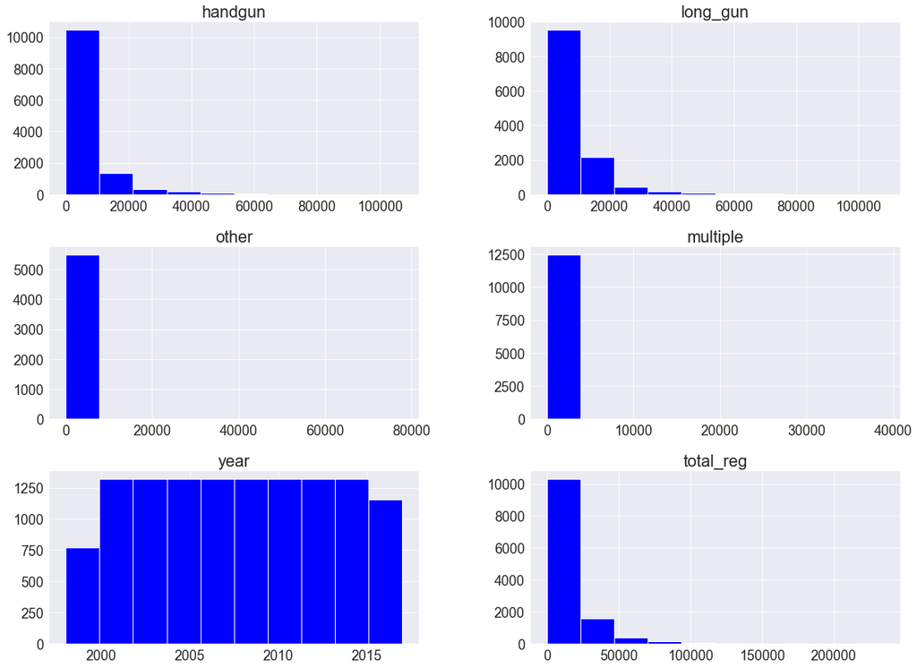

```python
gun_data.hist(figsize=(20, 15), color='blue');
```

###### I Have kept the general columns which are available for all years as a general Gun Data "gen_gun", notice that almost all data is very skewed to the right, so generally i will use median over the average (as the average will be somehow misleading)

## 2-Cleaning and preparing Census Data

> Generally During exploring this data set i have noticed that it needs a lot of cleaning, so my approach will be that, i will separate each year in a separate data set then I will exclude the rows that will not be related to my investigation

```python
census_data.tail(25)
```

|  | Fact | Fact Note | Alabama | Alaska | Arizona | Arkansas | California | Colorado | Connecticut | Delaware | ... | South Dakota | Tennessee | Texas | Utah | Vermont | Virginia | Washington | West Virginia | Wisconsin | Wyoming |
| --- | --- | --- | --- | --- | --- | --- | --- | --- | --- | --- | --- | --- | --- | --- | --- | --- | --- | --- | --- | --- | --- |
| 60 | Veteran-owned firms, 2012 | NaN | 41,943 | 7,953 | 46,780 | 25,915 | 252,377 | 51,722 | 31,056 | 7,206 | ... | 8604 | 59379 | 213,590 | 18,754 | 8,237 | 76,434 | 49,331 | 12,912 | 39,830 | 6,470 |
| 61 | Nonveteran-owned firms, 2012 | NaN | 316,984 | 56,091 | 427,582 | 192,988 | 3,176,341 | 469,524 | 281,182 | 60,318 | ... | 66219 | 469392 | 2,057,218 | 219,807 | 63,317 | 548,439 | 461,401 | 94,960 | 370,755 | 51,353 |
| 62 | Population per square mile, 2010 | NaN | 94.4 | 1.2 | 56.3 | 56 | 239.1 | 48.5 | 738.1 | 460.8 | ... | 10.7 | 153.9 | 96.3 | 33.6 | 67.9 | 202.6 | 101.2 | 77.1 | 105 | 5.8 |
| 63 | Land area in square miles, 2010 | NaN | 50,645.33 | 570,640.95 | 113,594.08 | 52,035.48 | 155,779.22 | 103,641.89 | 4,842.36 | 1,948.54 | ... | 75811 | 41234.9 | 261,231.71 | 82,169.62 | 9,216.66 | 39,490.09 | 66,455.52 | 24,038.21 | 54,157.80 | 97,093.14 |
| 64 | FIPS Code | NaN | "01" | "02" | "04" | "05" | "06" | "08" | "09" | "10" | ... | "46" | "47" | "48" | "49" | "50" | "51" | "53" | "54" | "55" | "56" |
| 65 | NaN | NaN | NaN | NaN | NaN | NaN | NaN | NaN | NaN | NaN | ... | NaN | NaN | NaN | NaN | NaN | NaN | NaN | NaN | NaN | NaN |
| 66 | NOTE: FIPS Code values are enclosed in quotes ... | NaN | NaN | NaN | NaN | NaN | NaN | NaN | NaN | NaN | ... | NaN | NaN | NaN | NaN | NaN | NaN | NaN | NaN | NaN | NaN |
| 67 | NaN | NaN | NaN | NaN | NaN | NaN | NaN | NaN | NaN | NaN | ... | NaN | NaN | NaN | NaN | NaN | NaN | NaN | NaN | NaN | NaN |
| 68 | Value Notes | NaN | NaN | NaN | NaN | NaN | NaN | NaN | NaN | NaN | ... | NaN | NaN | NaN | NaN | NaN | NaN | NaN | NaN | NaN | NaN |
| 69 | 1 | Includes data not distributed by county. | NaN | NaN | NaN | NaN | NaN | NaN | NaN | NaN | ... | NaN | NaN | NaN | NaN | NaN | NaN | NaN | NaN | NaN | NaN |
| 70 | NaN | NaN | NaN | NaN | NaN | NaN | NaN | NaN | NaN | NaN | ... | NaN | NaN | NaN | NaN | NaN | NaN | NaN | NaN | NaN | NaN |
| 71 | Fact Notes | NaN | NaN | NaN | NaN | NaN | NaN | NaN | NaN | NaN | ... | NaN | NaN | NaN | NaN | NaN | NaN | NaN | NaN | NaN | NaN |
| 72 | (a) | Includes persons reporting only one race | NaN | NaN | NaN | NaN | NaN | NaN | NaN | NaN | ... | NaN | NaN | NaN | NaN | NaN | NaN | NaN | NaN | NaN | NaN |
| 73 | (b) | Hispanics may be of any race, so also are incl... | NaN | NaN | NaN | NaN | NaN | NaN | NaN | NaN | ... | NaN | NaN | NaN | NaN | NaN | NaN | NaN | NaN | NaN | NaN |
| 74 | (c) | Economic Census - Puerto Rico data are not com... | NaN | NaN | NaN | NaN | NaN | NaN | NaN | NaN | ... | NaN | NaN | NaN | NaN | NaN | NaN | NaN | NaN | NaN | NaN |
| 75 | NaN | NaN | NaN | NaN | NaN | NaN | NaN | NaN | NaN | NaN | ... | NaN | NaN | NaN | NaN | NaN | NaN | NaN | NaN | NaN | NaN |
| 76 | Value Flags | NaN | NaN | NaN | NaN | NaN | NaN | NaN | NaN | NaN | ... | NaN | NaN | NaN | NaN | NaN | NaN | NaN | NaN | NaN | NaN |
| 77 | - | Either no or too few sample observations were ... | NaN | NaN | NaN | NaN | NaN | NaN | NaN | NaN | ... | NaN | NaN | NaN | NaN | NaN | NaN | NaN | NaN | NaN | NaN |
| 78 | D | Suppressed to avoid disclosure of confidential... | NaN | NaN | NaN | NaN | NaN | NaN | NaN | NaN | ... | NaN | NaN | NaN | NaN | NaN | NaN | NaN | NaN | NaN | NaN |
| 79 | F | Fewer than 25 firms | NaN | NaN | NaN | NaN | NaN | NaN | NaN | NaN | ... | NaN | NaN | NaN | NaN | NaN | NaN | NaN | NaN | NaN | NaN |
| 80 | FN | Footnote on this item in place of data | NaN | NaN | NaN | NaN | NaN | NaN | NaN | NaN | ... | NaN | NaN | NaN | NaN | NaN | NaN | NaN | NaN | NaN | NaN |
| 81 | NaN | Not available | NaN | NaN | NaN | NaN | NaN | NaN | NaN | NaN | ... | NaN | NaN | NaN | NaN | NaN | NaN | NaN | NaN | NaN | NaN |
| 82 | S | Suppressed; does not meet publication standards | NaN | NaN | NaN | NaN | NaN | NaN | NaN | NaN | ... | NaN | NaN | NaN | NaN | NaN | NaN | NaN | NaN | NaN | NaN |
| 83 | X | Not applicable | NaN | NaN | NaN | NaN | NaN | NaN | NaN | NaN | ... | NaN | NaN | NaN | NaN | NaN | NaN | NaN | NaN | NaN | NaN |
| 84 | Z | Value greater than zero but less than half uni... | NaN | NaN | NaN | NaN | NaN | NaN | NaN | NaN | ... | NaN | NaN | NaN | NaN | NaN | NaN | NaN | NaN | NaN | NaN |

25 rows × 52 columns

```python
cen_data = census_data.drop(index=census_data.iloc[64: ].index, columns='Fact Note').copy()
cen_data = cen_data.applymap(lambda item : item.replace(",","")) # removing String in order to be able to converet the data to Float
cen_data = cen_data.applymap(lambda item : item.replace("%",""))
cen_data = cen_data.applymap(lambda item : item.replace("$",""))
cen_data = cen_data.applymap(lambda item : item.replace("D", "NaN")) #replacing litters with NaN value as we cannot replce it with zeros or drop the all data
cen_data = cen_data.applymap(lambda item : item.replace("Z", "NaN"))
cen_data = cen_data.applymap(lambda item : item.replace("FN", "NaN"))
for name in cen_data.columns[1:]:
    cen_data[name] = cen_data[name].astype(float)
```

##### I have fixed the Data Type and removed the not needed column and rows

```python
def clean_census(dataframe:pd.DataFrame):
    dataframe = dataframe.transpose().reset_index()
    dataframe.columns = dataframe.iloc[0] # use the first row as a Header
    dataframe.drop(0, inplace=True) # Dropping the first Row
    dataframe.rename(columns={'Fact':'state'}, inplace=True) # change Column name from fact to State
    dataframe.rename(columns=(lambda x: x.strip().replace(" ","_").lower()), inplace=True) # Cleaning the header name
    for name in dataframe.columns[1:]:
        dataframe[name] = dataframe[name].astype(float) # Change all column Data type to Float
    return dataframe
```

```python
cen_2016 = cen_data[cen_data['Fact'].str.contains("2016")].reset_index(drop=True)
print(cen_2016.Fact)
cen_2016 = cen_2016.drop(cen_2016.iloc[7:].index) # removing not needed rows
cen_2016 = cen_2016.drop(index=[1, 2]).reset_index(drop=True) # removing not needed rows
cen_2016['Fact'] = cen_2016.Fact.apply(lambda x: x[:len(x)-21]) # Slicing the Fact Column by removing month and year name
print(cen_2016.Fact) # Just checking the result after dropping the rows
cen_2016 = clean_census(cen_2016)
cen_2016.rename(columns={'population_estimates':'population_census'}, inplace=True)#  change Column name to population_census just for consistency
```

```
0             Population estimates July 1 2016  (V2016)
1       Population estimates base April 1 2010  (V2016)
2     Population percent change - April 1 2010 (esti...
3     Persons under 5 years percent July 1 2016  (V2...
4     Persons under 18 years percent July 1 2016  (V...
5     Persons 65 years and over percent  July 1 2016...
6          Female persons percent  July 1 2016  (V2016)
7              White alone percent July 1 2016  (V2016)
8     Black or African American alone percent July 1...
9     American Indian and Alaska Native alone percen...
10             Asian alone percent July 1 2016  (V2016)
11    Native Hawaiian and Other Pacific Islander alo...
12       Two or More Races percent July 1 2016  (V2016)
13      Hispanic or Latino percent July 1 2016  (V2016)
14    White alone not Hispanic or Latino percent Jul...
15                  Housing units  July 1 2016  (V2016)
16                                Building permits 2016
Name: Fact, dtype: object
0                  Population estimates
1         Persons under 5 years percent
2        Persons under 18 years percent
3    Persons 65 years and over percent
4               Female persons percent
Name: Fact, dtype: object
```

```python
print(cen_2016.info())

cen_2016.head()
```

```
<class 'pandas.core.frame.DataFrame'>
Int64Index: 50 entries, 1 to 50
Data columns (total 6 columns):
 #   Column                             Non-Null Count  Dtype
---  ------                             --------------  -----
 0   state                              50 non-null     object
 1   population_census                  50 non-null     float64
 2   persons_under_5_years_percent      50 non-null     float64
 3   persons_under_18_years_percent     50 non-null     float64
 4   persons_65_years_and_over_percent  50 non-null     float64
 5   female_persons_percent             50 non-null     float64
dtypes: float64(5), object(1)
memory usage: 2.7+ KB
None
```

|  | state | population_census | persons_under_5_years_percent | persons_under_18_years_percent | persons_65_years_and_over_percent | female_persons_percent |
| --- | --- | --- | --- | --- | --- | --- |
| 1 | Alabama | 4863300.0 | 6.0 | 22.6 | 16.1 | 51.6 |
| 2 | Alaska | 741894.0 | 7.3 | 25.2 | 10.4 | 47.7 |
| 3 | Arizona | 6931071.0 | 6.3 | 23.5 | 16.9 | 50.3 |
| 4 | Arkansas | 2988248.0 | 6.4 | 23.6 | 16.3 | 50.9 |
| 5 | California | 39250017.0 | 6.3 | 23.2 | 13.6 | 50.3 |

##### Splitting Census Data related to 2016 and dropping the rows which not related to my investigation

```python
cen_2010  = cen_data[cen_data['Fact'].str.contains("2010")].reset_index(drop=True)
print(cen_2010.Fact)
cen_2010 = cen_2010.drop(index=[0,1,7,8,9]).reset_index(drop=True)# removing not needed rows
cen_2010['Fact'] = cen_2010.Fact.apply(lambda x: x[:len(x)-13])# Slicing the Fact Column by removing month and year name
print(cen_2010.Fact) # Just checking the result after dropping the rows
cen_2010 = clean_census(cen_2010)
```

```
0      Population estimates base April 1 2010  (V2016)
1    Population percent change - April 1 2010 (esti...
2                       Population Census April 1 2010
3           Persons under 5 years percent April 1 2010
4          Persons under 18 years percent April 1 2010
5       Persons 65 years and over percent April 1 2010
6                  Female persons percent April 1 2010
7                           Housing units April 1 2010
8                      Population per square mile 2010
9                       Land area in square miles 2010
Name: Fact, dtype: object
0                    Population Census
1        Persons under 5 years percent
2       Persons under 18 years percent
3    Persons 65 years and over percent
4               Female persons percent
Name: Fact, dtype: object
```

```python
print(cen_2010.info())
cen_2010.head()
```

```
<class 'pandas.core.frame.DataFrame'>
Int64Index: 50 entries, 1 to 50
Data columns (total 6 columns):
 #   Column                             Non-Null Count  Dtype
---  ------                             --------------  -----
 0   state                              50 non-null     object
 1   population_census                  50 non-null     float64
 2   persons_under_5_years_percent      50 non-null     float64
 3   persons_under_18_years_percent     50 non-null     float64
 4   persons_65_years_and_over_percent  50 non-null     float64
 5   female_persons_percent             50 non-null     float64
dtypes: float64(5), object(1)
memory usage: 2.7+ KB
None
```

|  | state | population_census | persons_under_5_years_percent | persons_under_18_years_percent | persons_65_years_and_over_percent | female_persons_percent |
| --- | --- | --- | --- | --- | --- | --- |
| 1 | Alabama | 4779736.0 | 6.4 | 23.7 | 13.8 | 51.5 |
| 2 | Alaska | 710231.0 | 7.6 | 26.4 | 7.7 | 48.0 |
| 3 | Arizona | 6392017.0 | 7.1 | 25.5 | 13.8 | 50.3 |
| 4 | Arkansas | 2915918.0 | 6.8 | 24.4 | 14.4 | 50.9 |
| 5 | California | 37253956.0 | 6.8 | 25.0 | 11.4 | 50.3 |

##### Splitting Census Data related to 2010 and dropping the rows which not related to my investigation

```python
cen_2012  = cen_data[cen_data['Fact'].str.contains("2012")].reset_index(drop=True)
print(cen_2012.Fact)
cen_2012 = cen_2012.query('Fact == "All firms 2012"')# removing not needed rows
cen_2012['Fact'] = cen_2012.Fact.apply(lambda x: x[:len(x)-5])# Slicing the Fact Column by removing month and year name
print(cen_2012.Fact) # Just checking the result after dropping the rows
cen_2012 = clean_census(cen_2012)
```

```
0     Total accommodation and food services sales 20...
1     Total health care and social assistance receip...
2             Total manufacturers shipments 2012 (1000)
3           Total merchant wholesaler sales 2012 (1000)
4                        Total retail sales 2012 (1000)
5                    Total retail sales per capita 2012
6                                        All firms 2012
7                                  Men-owned firms 2012
8                                Women-owned firms 2012
9                             Minority-owned firms 2012
10                         Nonminority-owned firms 2012
11                             Veteran-owned firms 2012
12                          Nonveteran-owned firms 2012
Name: Fact, dtype: object
6    All firms
Name: Fact, dtype: object
```

```python
print(cen_2012.info())
cen_2012.head()
```

```
<class 'pandas.core.frame.DataFrame'>
Int64Index: 50 entries, 1 to 50
Data columns (total 2 columns):
 #   Column     Non-Null Count  Dtype
---  ------     --------------  -----
 0   state      50 non-null     object
 1   all_firms  50 non-null     float64
dtypes: float64(1), object(1)
memory usage: 1.2+ KB
None
```

|  | state | all_firms |
| --- | --- | --- |
| 1 | Alabama | 374153.0 |
| 2 | Alaska | 68032.0 |
| 3 | Arizona | 499926.0 |
| 4 | Arkansas | 231959.0 |
| 5 | California | 3548449.0 |

##### Splitting Census Data related to 2012 and dropping the rows which not related to my investigation

## Exploratory Data Analysis

### Research Question 1: In General. What is the distribution of gun registrations over the years?

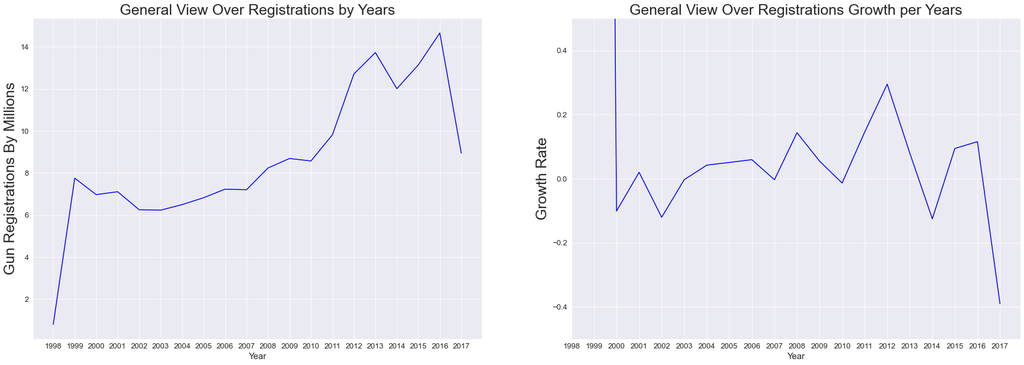

```python
matplotlib.rcParams.update({'font.size': 13}) # change General Graph font size

fig, ax = plt.subplots(nrows=1, ncols=2,figsize= (30,10))

dist_year = gun_data.groupby('year').total_reg.sum()/1000000
# Plotting results
ax[0].plot(dist_year.index,dist_year.values, color='blue')
ax[0].set(xticks= dist_year.index)
ax[0].set_xlabel('Year', fontsize=15)
ax[0].set_ylabel('Gun Registrations By Millions', fontsize=25);
ax[0].set_title('General View Over Registrations by Years', fontsize=25)
# second subplot
year_df = pd.DataFrame(dist_year).reset_index()
year_df['growth'] = year_df.total_reg.pct_change()
ax[1].plot(year_df.year, year_df.growth, color='blue')
ax[1].set(xticks= year_df.year, ylim=[-0.5,0.5])
ax[1].set_xlabel('Year', fontsize=15)
ax[1].set_ylabel('Growth Rate' , fontsize=25)
ax[1].set_title('General View Over Registrations Growth per Years', fontsize=25);
```

##### In the previous Graph, we noticed that since 1998 there is an increase in Gun registrations and except for 1999 which has the highest growth rate, notice that in 2012 we have the highest growth rate since 2000 till 2017, and for some reason, we have the lowest growth rate in 2017

### Research Question 2: In General. What is the distribution of gun registrations over the Monthes?

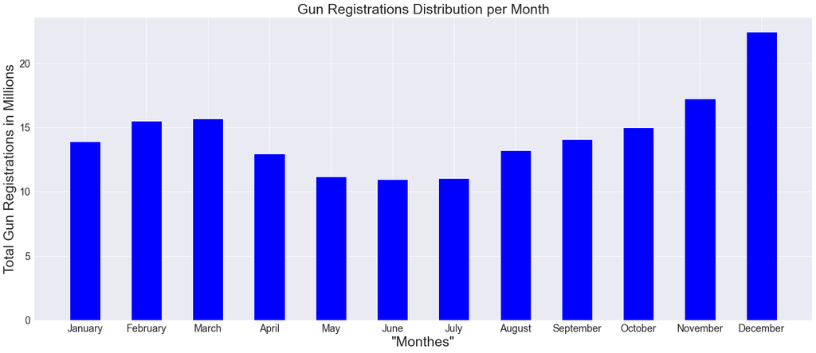

```python
matplotlib.rcParams.update({'font.size': 18}) # change General Graph font size
month_order = ['January', 'February', 'March', 'April', 'May', 'June','July', 'August', 'September', 'October', 'November', 'December']
gun_reg_month = (gun_data.groupby('month').total_reg.sum().reindex(index=month_order))/1000000 # Getting the top 10 states in gun registrations and divide it by 1 million to make the graph easy to read
fig, ax = plt.subplots(figsize= (25,10))
width = 0.50

# plot
ax.bar(gun_reg_month.index, gun_reg_month.values, width, color='blue')
ax.set_xlabel('"Monthes"', fontsize=25)
ax.set_ylabel('Total Gun Registrations in Millions' , fontsize=25)
ax.set_title('Gun Registrations Distribution per Month', fontsize=25);
```

#### Here we notice that "December" has the highest gun registrations rate

### Research Question 3: What is the overall trend of gun Registrations?

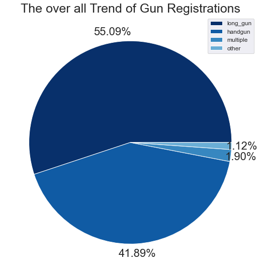

```python
gun_trend =  (gun_data[['long_gun','handgun','multiple','other']].sum())/1000000  # Getting the over all Trend in gun registrations and divide it by 1 million to make the graph easy to read
matplotlib.rcParams.update({'font.size': 22}) # change General Graph font size
fig = plt.figure(figsize = (8,7))

# Add set of axes to figure
axes = fig.add_axes([0.1, 0.1, 1, 1]) # left, bottom, width, height

# Plot on that set of axes

colors = plt.get_cmap('Blues')(np.linspace(1, 0.5, len(gun_trend)))
labels = gun_trend.index

axes.pie(gun_trend, colors=colors, radius=1, center=(1, 1), pctdistance=1.1,autopct='%1.2f%%', wedgeprops={"linewidth": 1, "edgecolor": "white"}, frame=False);
axes.legend(labels, loc=1, fontsize=12)

# Set Labels

axes.set_title('The over all Trend of Gun Registrations', fontsize=25);
```

##### In General there is a tendency to Have a long gun, and hand gun, but very few for other types

### Research Question 4: What is the Top 10 States in Gun Registration?

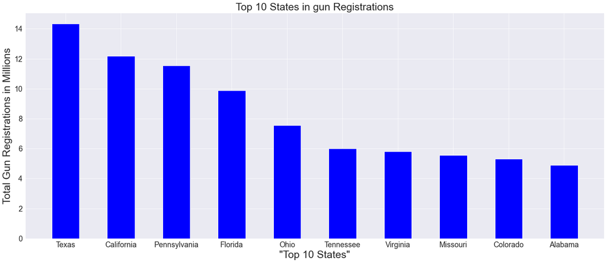

```python
matplotlib.rcParams.update({'font.size': 18}) # change General Graph font size

gun_reg_s = (gun_data.groupby('state').total_reg.sum().sort_values(ascending= False).head(10))/1000000 # Getting the top 10 states in gun registrations and divide it by 1 million to make the graph easy to read
fig, ax = plt.subplots(figsize= (25,10))

width = 0.50

# plot
ax.bar(gun_reg_s.index, gun_reg_s.values, width, color='blue')
ax.set_xlabel('"Top 10 States"', fontsize=25)
ax.set_ylabel('Total Gun Registrations in Millions' , fontsize=25)
ax.set_title('Top 10 States in gun Registrations', fontsize=25);
```

##### The Top 10 Satates in Gun Registrations are "'Texas', 'California', 'Pennsylvania', 'Florida', 'Ohio', 'Tennessee','Virginia', 'Missouri', 'Colorado', 'Alabama'"

### Research Question 5: Over the Top 10 States in gun Registrations what is the general trend of gun Type?

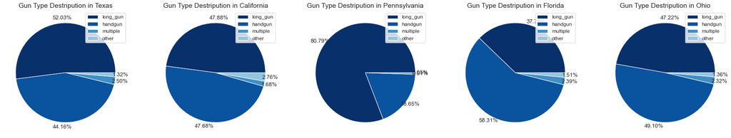

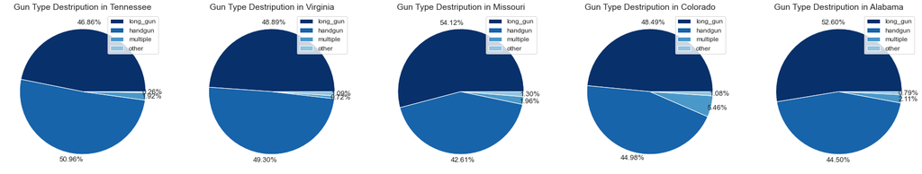

```python
sns.set_style('white') # change the Plot style
matplotlib.rcParams.update({'font.size': 13}) # change General Graph font size
state_rank = gun_data.groupby('state')[['total_reg','long_gun','handgun','multiple','other']].sum().sort_values(by='total_reg',ascending= False) # Grouping main data set by the state to get to top 10 and other calculations such as growth rate later
guns_per_state = state_rank.head(10) # Top 10 states

# plot
fig, ax = plt.subplots(nrows=1, ncols=5, figsize=(30,20)) # Setting plot figure and axes numbers per figure
row = 0
for axe in ax: #For loop to plot first 5 States statistics

    x = guns_per_state.iloc[row, 1:]
    colors = plt.get_cmap('Blues')(np.linspace(1.1, 0.4, len(x)))
    labels = guns_per_state.columns[1:]

    axe.pie(x, colors=colors, radius=1, center=(1, 1), pctdistance=1.1,autopct='%1.2f%%', wedgeprops={"linewidth": 1, "edgecolor": "white"}, frame=False, normalize=True);
    axe.legend(labels, loc=1, fontsize=12)
    axe.set_title(f'Gun Type Destripution in {guns_per_state.index[row]}')
    row += 1

fig2, ax2 = plt.subplots(nrows=1, ncols=5, figsize=(30,20))    # Setting plot figure and axes numbers per figure
for axe in ax2: #For loop to plot Second 5 States statistics

    x = guns_per_state.iloc[row, 1:]
    colors = plt.get_cmap('Blues')(np.linspace(1, 0.4, len(x)))
    labels = guns_per_state.columns[1:]

    axe.pie(x, colors=colors, radius=1, center=(1, 1), pctdistance=1.1,autopct='%1.2f%%', wedgeprops={"linewidth": 1, "edgecolor": "white"}, frame=False, normalize=True);
    axe.legend(labels, loc=1, fontsize=12)
    axe.set_title(f'Gun Type Destripution in {guns_per_state.index[row]}')
    row += 1
```

##### Considering Top 10 States, for Florida, Ohio, Virginia and Tennessee, they tending to have a Hand Gun, unlike the general Trend

### Research Question 6: Which states have had the highest growth in gun registrations?

```python
state_rank = state_rank.reset_index() # Setting new index to State rank variable which we used in previous question
```

```python
states_data = pd.DataFrame(gun_data.groupby(['state', 'year'])['total_reg'].sum()) # New data frame which grouped the general gun data by the States and the Year to calculate the growth rate
states_data.reset_index(level=[0,1], inplace=True)
states = states_data.copy() # Just creating new data frame which will be used to get growth rate per State
states['growth'] =  states['total_reg'].pct_change()
states.drop(states.index[(states.growth == np.inf) | (states.year == 1998) ], inplace=True)
states.dropna(inplace=True)
mean_G = states.groupby('state').growth.mean().sort_values(ascending=False).head(10) # Getting top 10 States by Average growth rate per State
median_G = states.groupby('state').growth.median().sort_values(ascending=False).head(10) # Getting top 10 States by Median growth rate per State
```

```python
state_rank['rank'] = state_rank['state'].index+1 # Getting the States Rank column by using the sorted "state_rank" variable which we have reseted its index
state_filter = state_rank.loc[:,['state','rank']] # Getting only the States and its rank to merge it with the "top 10 State per growth rate" data frame
#state_filter
mean_mrg = pd.DataFrame(mean_G).merge(state_filter, on='state') # merging the data to be used as below
median_mrg = pd.DataFrame(median_G).merge(state_filter, on='state') # merging the data to be used as below
```

```python
def plot_growth(merged_data, states_data, states, method): # Function for plotting Growth related figures for the entire section
    sns.set_style('white')
    # General look over the combined growth rate calculation with The States Rank to make sure that we are getting the right conclusion
    fig, ax = plt.subplots(1,2,figsize=(25,10))

    color = 'blue'
    ax[0].set_xlabel('Top 10 States',fontsize=25)
    ax[0].set_ylabel('Growth Rate', color=color, fontsize=25)
    ax[0].bar(merged_data['state'], merged_data['growth'],0.25, color='blue')
    ax[0].tick_params(axis='y', labelcolor=color)
    ax[0].tick_params(axis='x', labelcolor='black', rotation=70)
    ax[0].set_title(f"Top 10 States by {method} Growth Rate",fontsize=25)

    ax2 = ax[0].twinx()  # instantiate a second axes that shares the same x-axis
    ax2.grid(True)

    color = 'red'
    ax2.set_ylabel('State Rank', color=color, fontsize=25)  # we already handled the x-label with ax1
    ax2.plot(merged_data['state'], merged_data['rank'], color=color, marker="o", linestyle="--")
    ax2.set(yticks= merged_data['rank'], ylim=[60,1])
    ax2.tick_params(axis='y', labelcolor=color)

    # General look over the combined growth rate calculation with The State Gun registration per year, just a closer look to see how it became the first state in growth rate
    first_state = states_data[states_data['state'] == merged_data['state'][0]] # first State Related data
    color = 'blue'
    ax[1].bar(first_state.year, first_state.total_reg, color=color)
    ax[1].set_xticks(first_state.year)
    ax[1].tick_params(axis='x', labelcolor='black', rotation=70)
    ax[1].set_xlabel('Year', fontsize=25)
    ax[1].set_ylabel('Growth Rate' , fontsize=25, color=color)
    ax[1].set_title(f"General View Over Gun Registrations per Year for {merged_data['state'][0]}", fontsize=25);

    ax3 = ax[1].twinx()  # instantiate a second axes that shares the same x-axis
    ax3.grid(True)
    first_s_gro = states[states['state'] == merged_data['state'][0]]
    color = 'red'
    ax3.set_ylabel('State Growth Rate', color=color, fontsize=25)  # we already handled the x-label with ax1
    ax3.plot(first_s_gro['year'], first_s_gro['growth'], color=color, marker="o", linestyle="--")
    ax3.set(yticks= first_s_gro['growth'])
    ax3.tick_params(axis='y', labelcolor=color)


    plt.tight_layout()
```

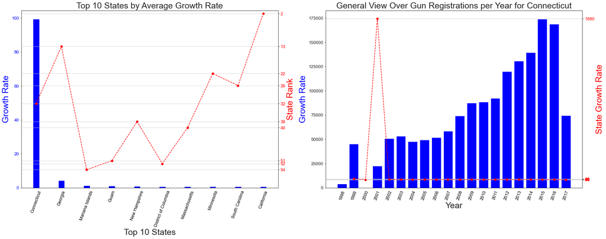

```python
plot_growth(mean_mrg, states_data, states, "Average") # Calling the above growth plotting function
```

##### As I Have mentioned before, using the Average method is misleading, and as we saw above "Connecticut" has an outlier value which is "1880" that affected our calculations

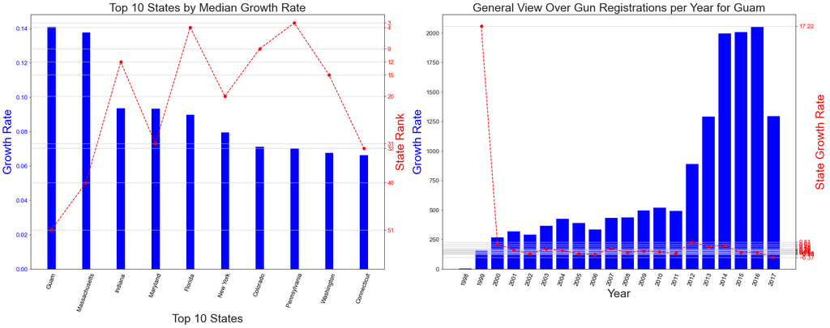

```python
plot_growth(median_mrg, states_data, states, 'Median') # Calling the above growth plotting function
```

#### Here we see that "Guam" has the highest growth rate, by calculating the median, but as we saw in the Gun Registrations for the same State that it has a very small Registrations rate considering the general trend "which is obvious in state registration rank", which will make the growth rate get high by any small change.

### Considering the above, I will take another approach by excluding all of the states that Have a Gun Registrations rate below the median of the General Trend, and then I will go through each method again to see the results

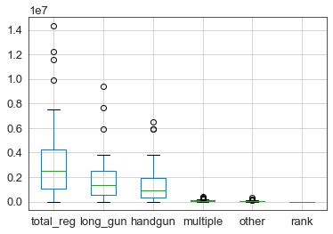

```python
top_states_rank = state_rank.query('total_reg > total_reg.median()') #Filtering on the states that has a general registration rate above the median
state_rank.boxplot(); # Just an overview to convey why we use the median over the mean
```

```python
top_states = pd.DataFrame(gun_data.groupby(['state', 'year'])['total_reg'].sum()) # New data frame which grouped the general gun data by the States and the Year to calculate the growth rate
top_states.reset_index(level=[0,1], inplace=True)
top_states.query(f'state == {list(top_states_rank.state.values)}', inplace=True)
states = top_states.copy() # Just creating new data frame which will be used to get growth rate per State
states['growth'] =  states['total_reg'].pct_change()#fill_method='ffill')
states.drop(states.index[(states.growth == np.inf) | (states.year == 1998) ], inplace=True)# dropping the infinity values and first year data as no growth rate for it
states.dropna(inplace=True)
mean_G = states.groupby('state').growth.mean().sort_values(ascending=False).head(10) # Getting top 10 States by Average growth rate per State
median_G = states.groupby('state').growth.median().sort_values(ascending=False).head(10) # Getting top 10 States by Median growth rate per State
```

```python
state_rank['rank'] = state_rank['state'].index+1 # Getting the States Rank column by using the sorted "state_rank" variable which we have reseted its index
state_filter = state_rank.loc[:,['state','rank']] # Getting only the States and its rank to merge it with the "top 10 State per growth rate" data frame
#state_filter
mean_mrg = pd.DataFrame(mean_G).merge(state_filter, on='state') # merging the data to be used as below
median_mrg = pd.DataFrame(median_G).merge(state_filter, on='state') # merging the data to be used as below
```

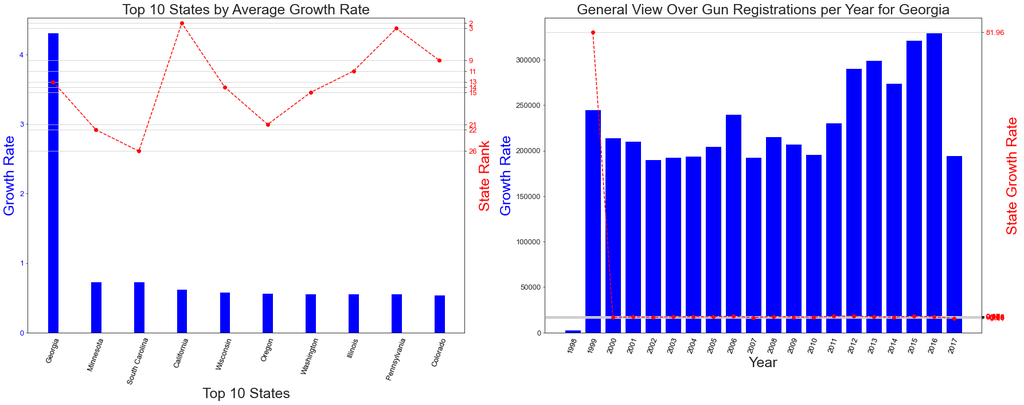

```python
plot_growth(mean_mrg, states_data, states, 'Average') # Calling the above growth plotting function
```

#### again, using the Average method is misleading, and as we saw above "Georgia" has an outlier value which is "82" that affected our calculations, that is applicable for all above 10 States

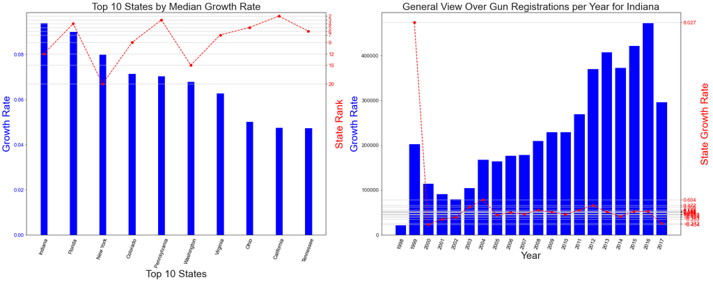

```python
plot_growth(median_mrg, states_data, states, 'Median') # Calling the above growth plotting function
```

## ***

### Research Question 7: for 2012 Data, what is the relation between gun registration and the number of firms?

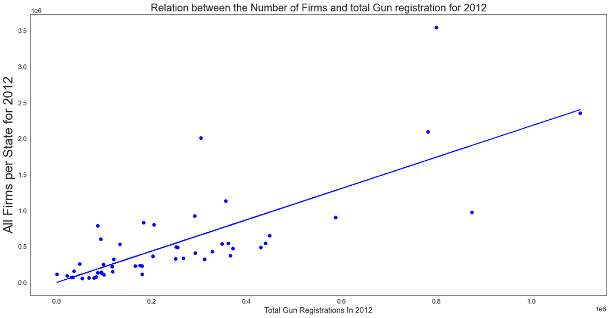

```python
gun_2012 = gun_data.query('year == 2012') # Filtering the gun Data by 2012 only.
states_2012 = gun_2012.groupby('state')[['total_reg','long_gun','handgun','multiple','other']].sum() # Grouping the Data by the state and extracting all gun types and total reg.
cen_gun_2012 = pd.merge(states_2012, cen_2012, on=['state']).sort_values(by='all_firms', ascending=False).reset_index(drop=True) # Mergeing Census Data with gun data to start our exploration on it

x = np.array(cen_gun_2012['total_reg'])# X axis Values
y = np.array(cen_gun_2012['all_firms'])# y axis Values

fig, ax = plt.subplots(figsize= (20,10))

# Plotting results
ax.scatter(x,y, color='blue')
m, b = np.polyfit(x, y, 1)  # Calculating the linear regression
ax.plot(x, (m*x + b), color='blue')
#Plot label
ax.set_xlabel('Total Gun Registrations In 2012', fontsize=15)
ax.set_ylabel('All Firms per State for 2012', fontsize=25);
ax.set_title('Relation between the Number of Firms and total Gun registration for 2012', fontsize=20);
```

#### For 2012 Census Data, generally there is a positive correlation between the Number of firms and Gun Registration

### Research Question 8: What census data is most associated with high gun per State?

#### Check For 2010 Census Data

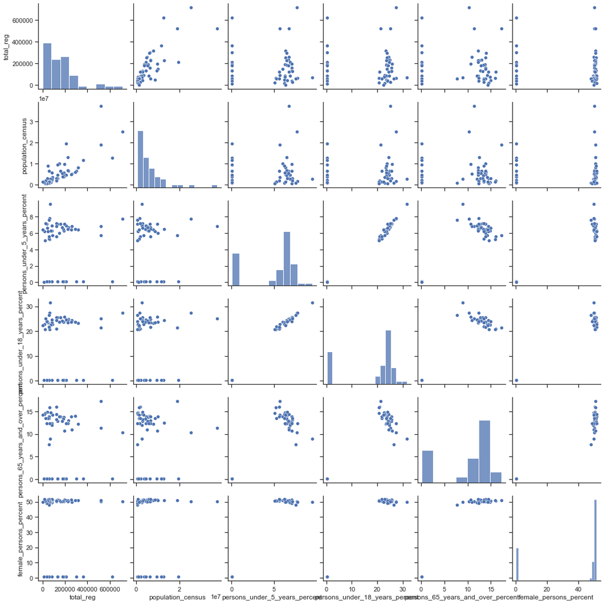

```python
gun_2010 = gun_data.query('year == 2010') # Filtering the gun Data by 2012 only.
states_2010 = gun_2010.groupby('state')[['total_reg','long_gun','handgun','multiple','other']].sum() # Grouping the Data by the state and extracting all gun types and total reg.
cen_gun_2010 = pd.merge(cen_2010, states_2010, on=['state']).sort_values(by='total_reg', ascending=False).reset_index(drop=True) # Mergeing Census Data with gun data to start our exploration on it

selected_view = cen_gun_2010[['total_reg','population_census', 'persons_under_5_years_percent', 'persons_under_18_years_percent', 'persons_65_years_and_over_percent','female_persons_percent']]
sns.set_theme(style="ticks")
sns.pairplot(selected_view);
```

```python
def plot_census(dataframe, year):
    x = np.array(dataframe['total_reg']) # X axis Values
    y = np.array(dataframe['population_census'])# y axis Values

    fig, ax = plt.subplots(figsize= (20,10))

    # Plotting results
    ax.scatter(x,y, color='blue')
    m, b = np.polyfit(x, y, 1)  # Calculating the linear regression
    ax.plot(x, (m*x + b), color='blue')
    #Plot label
    ax.set_xlabel(f'Total Gun Registrations In {year}', fontsize=15)
    ax.set_ylabel(f'Total Population census {year}', fontsize=25);
    ax.set_title(f'Relation between the Population census and total Gun registration for {year}', fontsize=20);
```

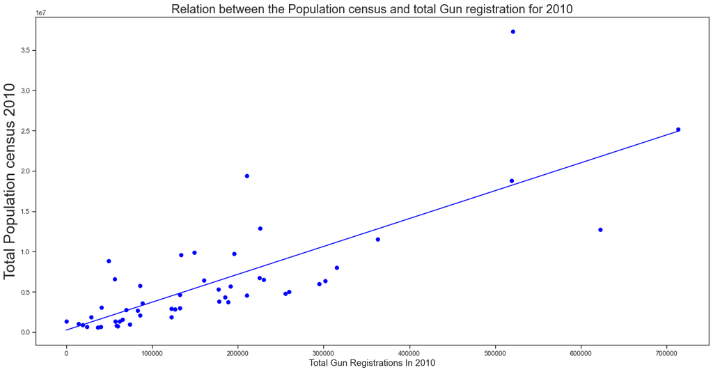

```python
plot_census(cen_gun_2010, 2010) # Calling the above plotting function
```

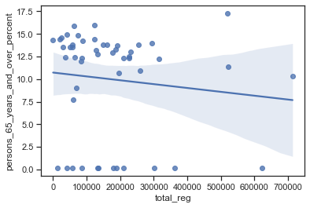

```python
sns.regplot(x='total_reg', y='persons_65_years_and_over_percent', data=cen_gun_2010);
```

#### Here For 2010 Census Data, generally there is a high association between population census and gun registration, and nothing is special for other data, except that i have noticed a negative correlation between the percentage for those how are 65 years old or above and the general gun registration

## ***

#### Check For 2016 Census Data

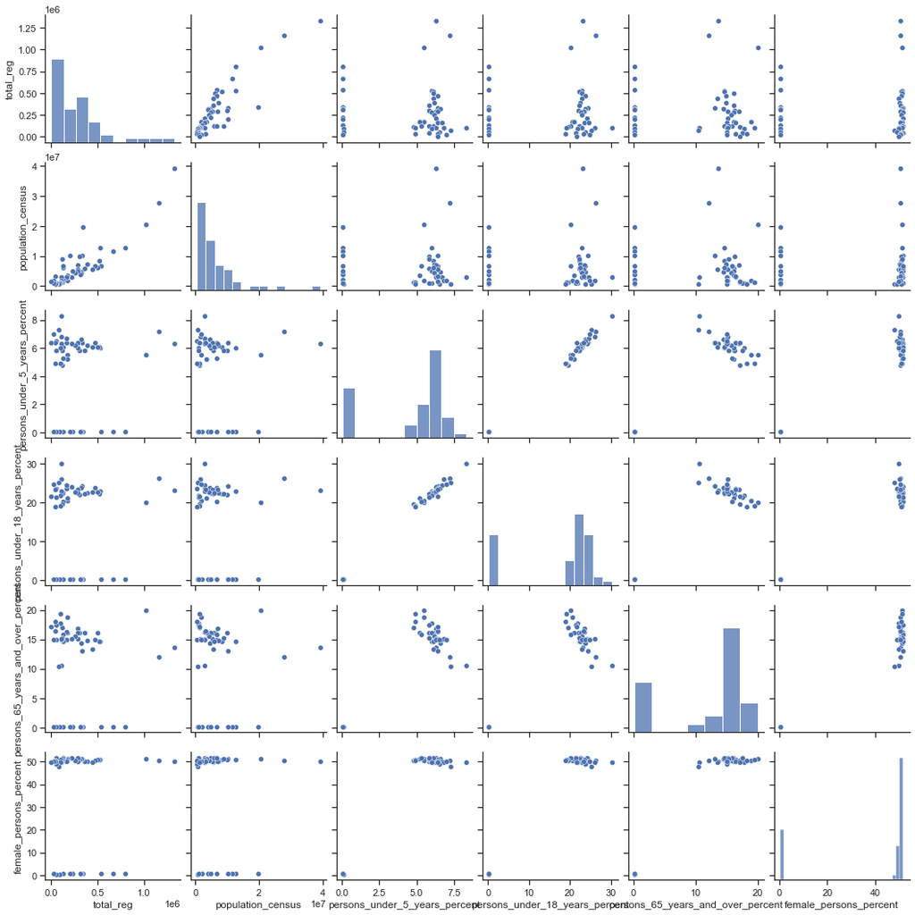

```python
gun_2016 = gun_data.query('year == 2016') # Filtering the gun Data by 2012 only.
states_2016 = gun_2016.groupby('state')[['total_reg','long_gun','handgun','multiple','other']].sum() # Grouping the Data by the state and extracting all gun types and total reg. i have kept all gun type to check if there is any association with census data
cen_gun_2016 = pd.merge(cen_2016, states_2016, on=['state']).sort_values(by='total_reg', ascending=False).reset_index(drop=True) # Mergeing Census Data with gun data to start our exploration on it
selected_view = cen_gun_2016[['total_reg','population_census', 'persons_under_5_years_percent', 'persons_under_18_years_percent', 'persons_65_years_and_over_percent','female_persons_percent']]

# pd.plotting.scatter_matrix(selected_view); # just an overview for census data and its association with gun registrations
sns.set_theme(style="ticks")
sns.pairplot(selected_view); # just an overview for census data and its association with gun registrations . better with seaborn
```

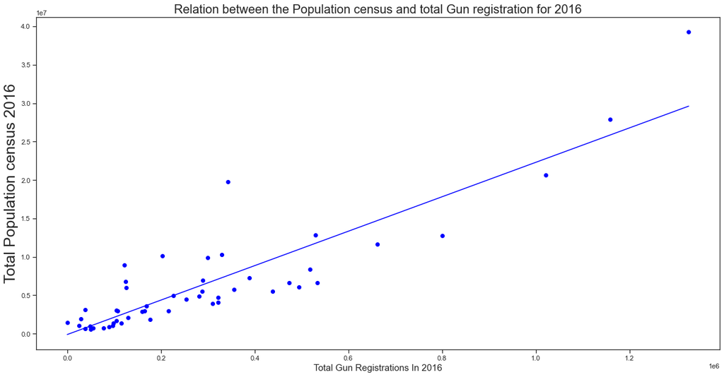

```python
plot_census(cen_gun_2016, 2016) # Calling the above plotting function
```

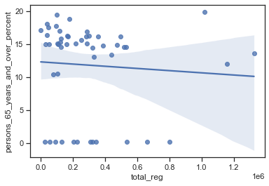

```python
sns.regplot(x='total_reg', y='persons_65_years_and_over_percent', data=cen_gun_2016);
```

#### Here For 2016 Census Data,also we have found that generally there is a high association between population census and gun registration, and nothing is special for other data, except that i have noticed a negative correlation between the percentage for those how are 65 years old or above and the general gun registration

# Conclusions

Before move to my conclusions there are some limitations related to data set, which need to be clear.

- The Data represent the number of firearm background checks initiated through the NICS. They do not represent the number of firearms sold
- there is not enough details about the admin and recheck permit criteria, which could be valuable if it was clear and consistent.
- for Census Data, it not including the data over the years as gun data set, so I have built my conclusions on the available data only
- for Census Data, it not including the data of all the States, so I have built my conclusions on the available data only
- for Census Data, total firms dose not equal the total of the separate numbers in data set, so i was forced to exclude it
- I could have built a relation module between total Income, employee percentage, and the criminal record percentage over the States if it was clearly defined